# 351 Assignment 1

James Sanii 20111876

RQ1.1: The two boroughs that will be analyzed in the following analysis are Brooklyn and Manhattan because I want to see data from a working class neighborhood(Brooklyn) and an upperclass neighborhood(Manhattan). Data on neighborhood income to determine class from: https://www.baruch.cuny.edu/nycdata/income-taxes/med_hhold_income.htm

RQ1.2: Hypothesis: Did COVID-19 impact the SALE.PRICE in the NYC real estate market? If so SALE.DATE should show an increase in the magnitude of correlation with SALE.PRICE and SALE.DATE in 2020 compared to passed years.

H0(null Hypothesis): There is no significant increase in correlation for how the sale date effects sale price between the years 2018, 2019 and 2020. Will be tested against by see if the magnitude of the correlation coefficient is larger in 2020 compared to past years.

Explanation: If COVID-19 affected the real estate market then the sale date should have a larger impact predicting sale price in 2020 compared to previous years since the market would be reacting to COVID-19 trends. So the value of the correlation coefficient should be significantly different in 2020 if COVID-19 effected the market. Also COVID-19 would start effecting the market at the end of February since COVID-19 was confirmed to be in NYC on February 29th. Link to CDC website for that data: https://www.cdc.gov/mmwr/volumes/69/wr/mm6946a2.htm#:~:text=Phylogenetic%20analysis%20and%20sentinel%20surveillance,was%20diagnosed%20on%20February%2029.

RQ1.3: I am going to use Pearson’s correlation Regression since I need to compare the effect that date has on price. Pearson correlation Regression analysis will allow me to compare the effect of sale date to the sale price. If COVID effected the Real Estate market then Sale Date should have a larger impact on Sale Price since that would suggest that the market is reacting to COVID-19 news. For the analysis I am using the datasets for each year. I also am going to remove all data entries with missing or questionable price data. Questionable price data includes $0 sales which means there was a transfer of ownership and other unreasonable sale prices which are likely to indicate the same thing. I also removed entities that are not residential units, this was done by removing entries that were not a taxcode 1 or 2 property. Entries that were incomplete were removed from the dataset in order to do regression analysis.For this strategy to work all variables in the regression analysis need to be normalized.

```r
library("lubridate")
library(e1071)
library(dplyr)
setwd("C:/Users/jcsan/Desktop/3rd year S2/CMPE 351/Assignment 1")

brooklyn18 = read.csv(file="2018_brooklyn.csv", header = TRUE, fill = TRUE)
brooklyn19 = read.csv(file="2019_brooklyn.csv", header = TRUE, fill = TRUE)
brooklyn20 = read.csv(file="2020_brooklyn.csv", header = TRUE, fill = TRUE)

sapply(brooklyn18,function(x)sum(is.na(x)))
```

```
                          ï..BOROUGH.                         NEIGHBORHOOD.
                                    0                                     0
             BUILDING.CLASS.CATEGORY.      TAX.CLASS.AS.OF.FINAL.ROLL.18.19
                                    0                                     0
                               BLOCK.                                  LOT.
                                    0                                     0
                           EASE.MENT. BUILDING.CLASS.AS.OF.FINAL.ROLL.18.19
                                23665                                     0
                             ADDRESS.                     APARTMENT.NUMBER.
                                    0                                     0
                            ZIP.CODE.                    RESIDENTIAL.UNITS.
                                    2                                     0
                    COMMERCIAL.UNITS.                          TOTAL.UNITS.
                                   15                                     0
                    LAND.SQUARE.FEET.                    GROSS.SQUARE.FEET.
                                    0                                     0
                          YEAR.BUILT.            TAX.CLASS.AT.TIME.OF.SALE.
                                    2                                     0
      BUILDING.CLASS.AT.TIME.OF.SALE.                           SALE.PRICE.
                                    0                                     0
                           SALE.DATE.
                                    0
```

```r
sapply(brooklyn19,function(x)sum(is.na(x)))
```

```
                          ï..BOROUGH.                         NEIGHBORHOOD.
                                  389                                     0
             BUILDING.CLASS.CATEGORY.      TAX.CLASS.AS.OF.FINAL.ROLL.18.19
                                    0                                     0
                               BLOCK.                                  LOT.
                                  389                                   389
                           EASE.MENT. BUILDING.CLASS.AS.OF.FINAL.ROLL.18.19
                                23665                                     0
                             ADDRESS.                     APARTMENT.NUMBER.
                                    0                                     0
                            ZIP.CODE.                    RESIDENTIAL.UNITS.
                                  389                                  3024
                    COMMERCIAL.UNITS.                          TOTAL.UNITS.
                                 3024                                  3024
                    LAND.SQUARE.FEET.                    GROSS.SQUARE.FEET.
                                    0                                     0
                          YEAR.BUILT.            TAX.CLASS.AT.TIME.OF.SALE.
                                 1989                                   389
      BUILDING.CLASS.AT.TIME.OF.SALE.                           SALE.PRICE.
                                    0                                     0
                           SALE.DATE.
                                    0
```

```r
sapply(brooklyn20,function(x)sum(is.na(x)))
```

```
                       BOROUGH                   NEIGHBORHOOD
                          5142                              0
       BUILDING.CLASS.CATEGORY           TAX.CLASS.AT.PRESENT
                             0                              0
                         BLOCK                            LOT
                          5142                           5142
                     EASE.MENT      BUILDING.CLASS.AT.PRESENT
                         23616                              0
                       ADDRESS               APARTMENT.NUMBER
                             0                              0
                      ZIP.CODE              RESIDENTIAL.UNITS
                          5143                           8068
              COMMERCIAL.UNITS                    TOTAL.UNITS
                         11095                           7375
              LAND.SQUARE.FEET              GROSS.SQUARE.FEET
                             0                              0
                    YEAR.BUILT      TAX.CLASS.AT.TIME.OF.SALE
                          6410                           5142
BUILDING.CLASS.AT.TIME.OF.SALE                     SALE.PRICE
                             0                              0
                     SALE.DATE
                             0
```

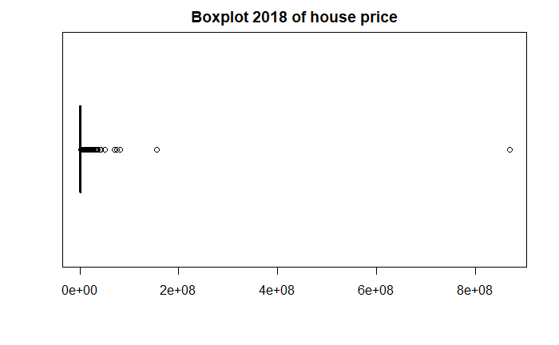

```r
x<-as.Date("2018-01-01")
brooklyn18$SALE.DATE. <- as.Date(brooklyn18$SALE.DATE.)
brooklyn18$SALE.DATE. <- as.numeric(brooklyn18$SALE.DATE. - as.numeric(x))
x<-as.Date("2019-01-01")
brooklyn19$SALE.DATE. <- as.Date(brooklyn19$SALE.DATE.)
brooklyn19$SALE.DATE. <- as.numeric(brooklyn19$SALE.DATE. - as.numeric(x))
x<-as.Date("2020-01-01")
brooklyn20$SALE.DATE <- as.Date(brooklyn20$SALE.DATE)
brooklyn20$SALE.DATE <- as.numeric(brooklyn20$SALE.DATE - as.numeric(x))

brooklyn18$SALE.PRICE. <- as.numeric(gsub('[$,]', '', brooklyn18$SALE.PRICE.))
brooklyn18<-brooklyn18[!(brooklyn18$SALE.PRICE. < 20),]
brooklyn19$SALE.PRICE. <- as.numeric(gsub('[$,]', '', brooklyn19$SALE.PRICE.))
brooklyn19<-brooklyn19[!(brooklyn19$SALE.PRICE. < 20),]
brooklyn20$SALE.PRICE <- as.numeric(gsub('[$,]', '', brooklyn20$SALE.PRICE))
brooklyn20<-brooklyn20[!(brooklyn20$SALE.PRICE < 20),]

#remove none residential real estate
brooklyn18<-brooklyn18[!(brooklyn18$TAX.CLASS.AT.TIME.OF.SALE. > 2),]
brooklyn19<-brooklyn19[!(brooklyn19$TAX.CLASS.AT.TIME.OF.SALE. > 2),]
brooklyn20<-brooklyn20[!(brooklyn20$TAX.CLASS.AT.TIME.OF.SALE > 2),]

brooklyn18<-select(brooklyn18, -c(EASE.MENT.))
brooklyn19<-select(brooklyn19, -c(EASE.MENT.))
brooklyn20<-select(brooklyn20, -c(EASE.MENT))

#setting residential units and commercial units NA values to 0 since most residential/commercial units would have 0 of the other
brooklyn18$RESIDENTIAL.UNITS.[is.na(brooklyn18$RESIDENTIAL.UNITS.)] <- 0
brooklyn19$RESIDENTIAL.UNITS.[is.na(brooklyn19$RESIDENTIAL.UNITS.)] <- 0
brooklyn20$RESIDENTIAL.UNITS[is.na(brooklyn20$RESIDENTIAL.UNITS)] <- 0
brooklyn18$COMMERCIAL.UNITS.[is.na(brooklyn18$COMMERCIAL.UNITS.)] <- 0
brooklyn19$COMMERCIAL.UNITS.[is.na(brooklyn19$COMMERCIAL.UNITS.)] <- 0
brooklyn20$COMMERCIAL.UNITS[is.na(brooklyn20$COMMERCIAL.UNITS)] <- 0

#I lose a lot of the 2020 dataset due to missing data but keeping the missing points or replacing with mean or median values would greatly effect the model because of the volume of missing data
final18 <- na.omit(brooklyn18)
final19 <- na.omit(brooklyn19)
final20 <- na.omit(brooklyn20)

#remove outliers to fix skewness issue after log transform
#boxplot used to help identify outliers
boxplot(final18$SALE.PRICE., horizontal=TRUE, main="Boxplot 2018 of house price")
```

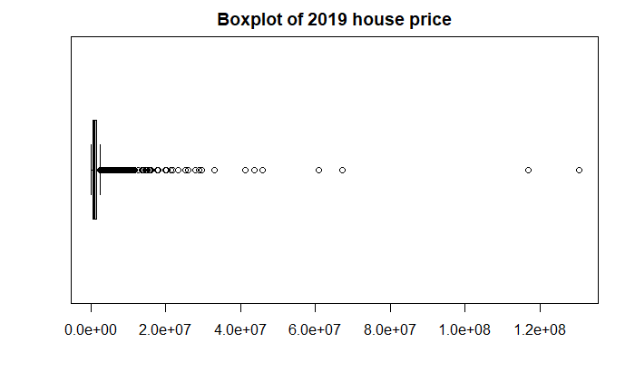

```r
boxplot(final19$SALE.PRICE., horizontal=TRUE, main="Boxplot of 2019 house price")
```

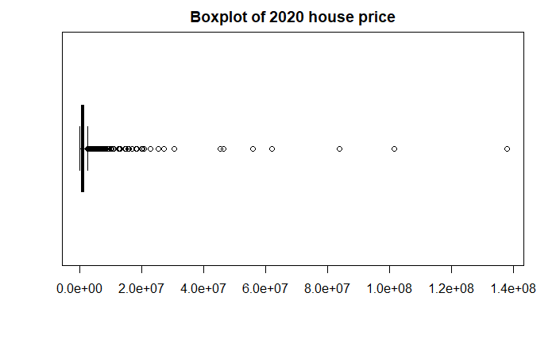

```r
boxplot(final20$SALE.PRICE, horizontal=TRUE, main="Boxplot of 2020 house price")
```

```r
final18 <- subset(final18, final18$SALE.PRICE. < quantile(final18$SALE.PRICE., 0.98))

final19 <- subset(final19, final19$SALE.PRICE. < quantile(final19$SALE.PRICE., 0.98))

final20 <- subset(final20, final20$SALE.PRICE < quantile(final20$SALE.PRICE, 0.98))

#shows right skew of SALE.PRICE
skewness(final18$SALE.PRICE)
```

```
[1] 1.645857
```

```r
skewness(final19$SALE.PRICE)
```

```
[1] 2.073415
```

```r
skewness(final20$SALE.PRICE)
```

```
[1] 1.862013
```

```r
#correct right skewness as much as possible, 2019 and 2020 data are over-corrected and are now left skewed. This was corrected by removing outliers above before doing the log transform

final18$SALE.PRICE <- scale(log(final18$SALE.PRICE),center=TRUE, scale = TRUE)
final19$SALE.PRICE <- scale(log(final19$SALE.PRICE),center=TRUE, scale = TRUE)
final20$SALE.PRICE <- scale(log(final20$SALE.PRICE),center=TRUE, scale = TRUE)
skewness(final18$SALE.PRICE)
```

```
[1] -3.06022
```

```r
skewness(final19$SALE.PRICE)
```

```
[1] -4.722659
```

```r
skewness(final20$SALE.PRICE)
```

```
[1] -3.887626
```

```r
#shows SALE.DATE is not skewed
skewness(final18$SALE.DATE)
```

```
[1] -0.0005644955
```

```r
skewness(final19$SALE.DATE)
```

```
[1] -0.02332457
```

```r
skewness(final20$SALE.DATE)
```

```
[1] -0.02007289
```

```r
#corelation between date and price
my_data <- dplyr::select(final18, SALE.DATE., SALE.PRICE.)
cormatbrooklyn18<-signif(cor(my_data),2)
cormatbrooklyn18
```

```
            SALE.DATE. SALE.PRICE.
SALE.DATE.      1.0000     -0.0015
SALE.PRICE.    -0.0015      1.0000
```

```r
my_data <- dplyr::select(final19, SALE.DATE., SALE.PRICE.)
cormatbrooklyn19<-signif(cor(my_data),2)
cormatbrooklyn19
```

```
            SALE.DATE. SALE.PRICE.
SALE.DATE.       1.000      -0.006
SALE.PRICE.     -0.006       1.000
```

```r
my_data <- dplyr::select(final20, SALE.DATE, SALE.PRICE)
cormatbrooklyn20<-signif(cor(my_data),2)
cormatbrooklyn20
```

```
           SALE.DATE SALE.PRICE
SALE.DATE      1.000      0.062
SALE.PRICE     0.062      1.000
```

For Brooklyn the correlation coefficient went from negative in 2018 and 2019 to positive in 2020. The magnitude of 2020 coefficient is significantly larger than past years(41 times 2018, 10 times 2019) which signifies that prices changed more throughout the year than previous years. It being positive signifies that sale prices increased over the year whereas past years it has decreased.

Now going to repeat the process for Manhattan data.

```r
library("lubridate")
library(e1071)
library(dplyr)
setwd("C:/Users/jcsan/Desktop/3rd year S2/CMPE 351/Assignment 1")

manhattan18 = read.csv(file="2018_manhattan.csv", header = TRUE, fill = TRUE)
manhattan19 = read.csv(file="2019_manhattan.csv", header = TRUE, fill = TRUE)
manhattan20 = read.csv(file="2020_manhattan.csv", header = TRUE, fill = TRUE)

sapply(manhattan18,function(x)sum(is.na(x)))
```

```
                          ï..BOROUGH.                         NEIGHBORHOOD.
                                    0                                     0
             BUILDING.CLASS.CATEGORY.      TAX.CLASS.AS.OF.FINAL.ROLL.18.19
                                    0                                     0
                               BLOCK.                                  LOT.
                                    0                                     0
                           EASE.MENT. BUILDING.CLASS.AS.OF.FINAL.ROLL.18.19
                                17041                                     0
                             ADDRESS.                     APARTMENT.NUMBER.
                                    0                                     0
                            ZIP.CODE.                    RESIDENTIAL.UNITS.
                                    0                                     1
                    COMMERCIAL.UNITS.                          TOTAL.UNITS.
                                    1                                     1
                    LAND.SQUARE.FEET.                    GROSS.SQUARE.FEET.
                                    0                                     0
                          YEAR.BUILT.            TAX.CLASS.AT.TIME.OF.SALE.
                                    0                                     0
      BUILDING.CLASS.AT.TIME.OF.SALE.                           SALE.PRICE.
                                    0                                     0
                           SALE.DATE.
                                    0
```

```r
sapply(manhattan19,function(x)sum(is.na(x)))
```

```
                          ï..BOROUGH.                         NEIGHBORHOOD.
                                    0                                     0
             BUILDING.CLASS.CATEGORY.      TAX.CLASS.AS.OF.FINAL.ROLL.18.19
                                    0                                     0
                               BLOCK.                                  LOT.
                                    0                                     0
                           EASE.MENT. BUILDING.CLASS.AS.OF.FINAL.ROLL.18.19
                                17583                                     0
                             ADDRESS.                     APARTMENT.NUMBER.
                                    0                                     0
                            ZIP.CODE.                    RESIDENTIAL.UNITS.
                                    0                                  7771
                    COMMERCIAL.UNITS.                          TOTAL.UNITS.
                                 7771                                  7771
                    LAND.SQUARE.FEET.                    GROSS.SQUARE.FEET.
                                    0                                     0
                          YEAR.BUILT.            TAX.CLASS.AT.TIME.OF.SALE.
                                 2051                                     0
      BUILDING.CLASS.AT.TIME.OF.SALE.                           SALE.PRICE.
                                    0                                     0
                           SALE.DATE.
                                    0
```

```r
sapply(manhattan20,function(x)sum(is.na(x)))
```

```
                    ï..BOROUGH                   NEIGHBORHOOD
                          5796                              0
       BUILDING.CLASS.CATEGORY           TAX.CLASS.AT.PRESENT
                             0                              0
                         BLOCK                            LOT
                          5796                           5796
                     EASE.MENT      BUILDING.CLASS.AT.PRESENT
                         17762                              0
                       ADDRESS               APARTMENT.NUMBER
                             0                              0
                      ZIP.CODE              RESIDENTIAL.UNITS
                          5796                              0
              COMMERCIAL.UNITS                    TOTAL.UNITS
                         16184                              0
              LAND.SQUARE.FEET              GROSS.SQUARE.FEET
                             0                              0
                    YEAR.BUILT      TAX.CLASS.AT.TIME.OF.SALE
                          7148                           5796
BUILDING.CLASS.AT.TIME.OF.SALE                     SALE.PRICE
                             0                              0
                     SALE.DATE
                             0
```

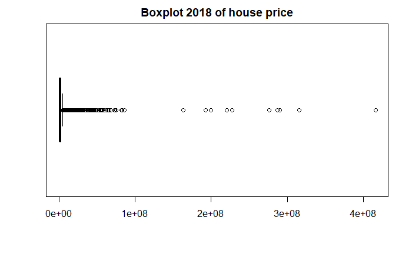

```r
#standardize date. first day of year = 0 last = 365
x<-as.Date("2018-01-01")
manhattan18$SALE.DATE. <- as.Date(manhattan18$SALE.DATE.)
manhattan18$SALE.DATE. <- as.numeric(manhattan18$SALE.DATE. - as.numeric(x))
x<-as.Date("2019-01-01")
manhattan19$SALE.DATE. <- as.Date(manhattan19$SALE.DATE.)
manhattan19$SALE.DATE. <- as.numeric(manhattan19$SALE.DATE. - as.numeric(x))
x<-as.Date("2020-01-01")
manhattan20$SALE.DATE <- as.Date(manhattan20$SALE.DATE)
manhattan20$SALE.DATE <- as.numeric(manhattan20$SALE.DATE - as.numeric(x))


manhattan18$SALE.PRICE. <- as.numeric(gsub('[$,]', '', manhattan18$SALE.PRICE.))
manhattan18<-manhattan18[!(manhattan18$SALE.PRICE. < 20),]
manhattan19$SALE.PRICE. <- as.numeric(gsub('[$,]', '', manhattan19$SALE.PRICE.))
manhattan19<-manhattan19[!(manhattan19$SALE.PRICE. < 20),]
manhattan20$SALE.PRICE <- as.numeric(gsub('[$,]', '', manhattan20$SALE.PRICE))
manhattan20<-manhattan20[!(manhattan20$SALE.PRICE < 20),]

manhattan18<-select(manhattan18, -c(EASE.MENT.))
manhattan19<-select(manhattan19, -c(EASE.MENT.))
manhattan20<-select(manhattan20, -c(EASE.MENT))

#remove non residential real estate
manhattan18<-manhattan18[!(manhattan18$TAX.CLASS.AT.TIME.OF.SALE. > 2),]
manhattan19<-manhattan19[!(manhattan19$TAX.CLASS.AT.TIME.OF.SALE. > 2),]
manhattan20<-manhattan20[!(manhattan20$TAX.CLASS.AT.TIME.OF.SALE > 2),]

#setting residential units and commercial units NA values to 0 since most residential/commercial units would have 0 of the other
manhattan18$RESIDENTIAL.UNITS.[is.na(manhattan18$RESIDENTIAL.UNITS.)] <- 0
manhattan19$RESIDENTIAL.UNITS.[is.na(manhattan19$RESIDENTIAL.UNITS.)] <- 0
manhattan20$RESIDENTIAL.UNITS[is.na(manhattan20$RESIDENTIAL.UNITS)] <- 0
manhattan18$COMMERCIAL.UNITS.[is.na(manhattan18$COMMERCIAL.UNITS.)] <- 0
manhattan19$COMMERCIAL.UNITS.[is.na(manhattan19$COMMERCIAL.UNITS.)] <- 0
manhattan20$COMMERCIAL.UNITS[is.na(manhattan20$COMMERCIAL.UNITS)] <- 0

final18 <- na.omit(manhattan18)
final19 <- na.omit(manhattan19)
final20 <- na.omit(manhattan20)


#remove outliers to fix skewness issue after log transform
boxplot(final18$SALE.PRICE., horizontal=TRUE, main="Boxplot 2018 of house price")
```

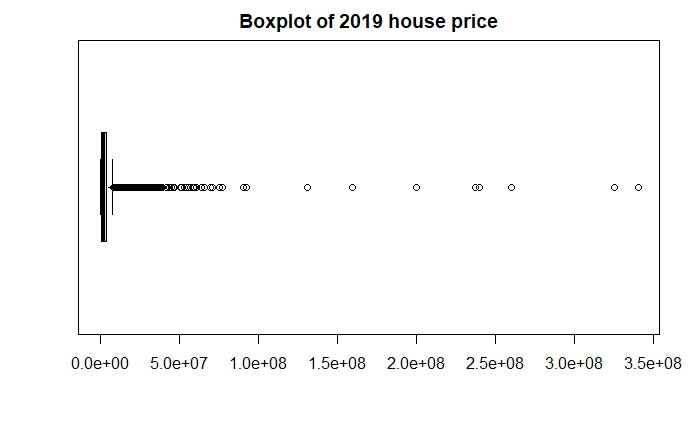

```r
boxplot(final19$SALE.PRICE., horizontal=TRUE, main="Boxplot of 2019 house price")
```

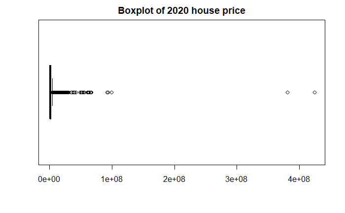

```r
boxplot(final20$SALE.PRICE, horizontal=TRUE, main="Boxplot of 2020 house price")
```

```r
final19 <- subset(final19, final19$SALE.PRICE. > quantile(final19$SALE.PRICE., 0.001))

final20 <- subset(final20, final20$SALE.PRICE < quantile(final20$SALE.PRICE, 0.98))


library(e1071)
#shows right skew of SALE.PRICE
skewness(final18$SALE.PRICE)
```

```
[1] 25.63572
```

```r
skewness(final19$SALE.PRICE)
```

```
[1] 17.30737
```

```r
skewness(final20$SALE.PRICE)
```

```
[1] 2.494673
```

```r
#correct right skewness as much as possible, 2019 and 2020 data are over-corrected and are now left skewed. This was corrected by removing outliers above before doing the log transform

final18$SALE.PRICE <- scale(log(final18$SALE.PRICE),center=TRUE, scale = TRUE)
final19$SALE.PRICE <- scale(log(final19$SALE.PRICE),center=TRUE, scale = TRUE)
final20$SALE.PRICE <- scale((final20$SALE.PRICE)^(1/3),center=TRUE, scale = TRUE)
skewness(final18$SALE.PRICE)
```

```
[1] -0.25913
```

```r
skewness(final19$SALE.PRICE)
```

```
[1] -0.3222447
```

```r
skewness(final20$SALE.PRICE)
```

```
[1] 0.8588024
```

```r
#shows SALE.DATE is not skewed
skewness(final18$SALE.DATE)
```

```
[1] -0.006204595
```

```r
skewness(final19$SALE.DATE)
```

```
[1] 0.1155998
```

```r
skewness(final20$SALE.DATE)
```

```
[1] 0.1398817
```

```r
#correlation between date and price
my_data <- dplyr::select(final18, SALE.DATE., SALE.PRICE.)
cormatmanhattan18<-signif(cor(my_data),2)
cormatmanhattan18
```

```
            SALE.DATE. SALE.PRICE.
SALE.DATE.       1.000       0.017
SALE.PRICE.      0.017       1.000
```

```r
my_data <- dplyr::select(final19, SALE.DATE., SALE.PRICE.)
cormatmanhattan19<-signif(cor(my_data),2)
cormatmanhattan19
```

```
            SALE.DATE. SALE.PRICE.
SALE.DATE.      1.0000     -0.0043
SALE.PRICE.    -0.0043      1.0000
```

```r
my_data <- dplyr::select(final20, SALE.DATE, SALE.PRICE)
cormatmanhattan20<-signif(cor(my_data),2)
cormatmanhattan20
```

```
           SALE.DATE SALE.PRICE
SALE.DATE      1.000      0.024
SALE.PRICE     0.024      1.000
```

Note: The significant change in price over the year 2020 could be because of a change in what type of property is being sold over 2020 and not because COVID-19 increased market value of the properties. This was not tested in the above analysis. The above analysis tested if COVID-19 effected the market, not how did COVID-19 effect the market.

Part 2: Feature Selection and Multicollinearity analysis

RQ2.1:I am only going to use the 2020 data since in part Q1 it showed that the importance of SALE.DATE changed significantly between 2020 and past years showing that there can be meaningful differences in correlation of variables depending on which year’s dataset is used. So using 2018 and 2019 to train a 2020 prediction model is a bad idea since the correlation coefficients of variables vary significantly.

```r
library(e1071)
library(dplyr)
#load files in
brooklyn20 = read.csv(file="2020_brooklyn.csv", header = TRUE, fill = TRUE)
manhattan20 = read.csv(file="2020_manhattan.csv", header = TRUE, fill = TRUE)
names(manhattan20)[names(manhattan20) == "ï..BOROUGH"] <- "BOROUGH"

total <- rbind(brooklyn20, manhattan20)

#RQ2.2 start

#categorical or numerical
str(total)
```

```
'data.frame':   41378 obs. of  21 variables:
 $ BOROUGH                       : int  3 3 3 3 3 3 3 3 3 3 ...
 $ NEIGHBORHOOD                  : chr  "BATH BEACH" "BATH BEACH" "BATH BEACH" "BATH BEACH" ...
 $ BUILDING.CLASS.CATEGORY       : chr  "01 ONE FAMILY DWELLINGS" "01 ONE FAMILY DWELLINGS" "01 ONE FAMILY DWELLINGS" "01 ONE FAMILY DWELLINGS" ...
 $ TAX.CLASS.AT.PRESENT          : chr  "1" "1" "1" "1" ...
 $ BLOCK                         : int  6359 6360 6360 6362 6367 6371 6371 6392 6392 6399 ...
 $ LOT                           : int  70 48 56 23 24 19 60 65 115 13 ...
 $ EASE.MENT                     : logi  NA NA NA NA NA NA ...
 $ BUILDING.CLASS.AT.PRESENT     : chr  "S1" "A5" "A5" "A9" ...
 $ ADDRESS                       : chr  "8684 15TH AVENUE" "14 BAY 10TH STREET" "30 BAY 10TH STREET" "43 BAY 11TH STREET" ...
 $ APARTMENT.NUMBER              : chr  "" "" "" "" ...
 $ ZIP.CODE                      : int  11228 11228 11228 11228 11214 11214 11214 11228 11228 11214 ...
 $ RESIDENTIAL.UNITS             : chr  "1" "1" "1" "1" ...
 $ COMMERCIAL.UNITS              : int  1 0 0 0 0 0 0 0 0 0 ...
 $ TOTAL.UNITS                   : chr  "2" "1" "1" "1" ...
 $ LAND.SQUARE.FEET              : chr  "1,933" "2,513" "1,547" "2,280" ...
 $ GROSS.SQUARE.FEET             : chr  "4,080" "1,428" "1,428" "1,052" ...
 $ YEAR.BUILT                    : int  1930 1930 1930 1901 1935 1930 1930 1940 1945 1930 ...
 $ TAX.CLASS.AT.TIME.OF.SALE     : int  1 1 1 1 1 1 1 1 1 1 ...
 $ BUILDING.CLASS.AT.TIME.OF.SALE: chr  "S1" "A5" "A5" "A9" ...
 $ SALE.PRICE                    : chr  "1,300,000" "849,000" "75,000" "0" ...
 $ SALE.DATE                     : chr  "2020-04-28" "2020-03-18" "2020-11-30" "2020-11-04" ...
```

```r
#feature transformations
total$SALE.PRICE <- as.numeric(gsub('[$,]', '', total$SALE.PRICE))
total<-total[!(total$SALE.PRICE < 20),]
x<-as.Date("2020-01-01")
total$SALE.DATE <- as.Date(total$SALE.DATE)
total$SALE.DATE <- as.numeric(total$SALE.DATE - as.numeric(x))
total<-select(total, -c(EASE.MENT))
total<-select(total, -c(APARTMENT.NUMBER))
total<-select(total, -c(NEIGHBORHOOD))
total<-select(total, -c(ADDRESS))
total$RESIDENTIAL.UNITS<-as.integer(total$RESIDENTIAL.UNITS)
```

```
NAs introduced by coercion
```

```r
total$TOTAL.UNITS <- as.integer(gsub('[$,]', '', total$TOTAL.UNITS))
total$LAND.SQUARE.FEET <- as.numeric(gsub('[$,]', '', total$LAND.SQUARE.FEET))
total$GROSS.SQUARE.FEET<- as.numeric(gsub('[$,]', '', total$GROSS.SQUARE.FEET))

#remove non-residential properties
total<-total[!(total$TAX.CLASS.AT.TIME.OF.SALE > 2),]
#remove na values and replace them with 0
total$RESIDENTIAL.UNITS[is.na(total$RESIDENTIAL.UNITS) & !(is.na(total$COMMERCIAL.UNITS))] <- 0
total$COMMERCIAL.UNITS[is.na(total$COMMERCIAL.UNITS) & !(is.na(total$RESIDENTIAL.UNITS))] <- 0

sapply(total,function(x)sum(is.na(x)))
```

```
                       BOROUGH        BUILDING.CLASS.CATEGORY
                         10938                          10938
          TAX.CLASS.AT.PRESENT                          BLOCK
                         10938                          10938
                           LOT      BUILDING.CLASS.AT.PRESENT
                         10938                          10938
                      ZIP.CODE              RESIDENTIAL.UNITS
                         10938                          17337
              COMMERCIAL.UNITS                    TOTAL.UNITS
                         17337                          17337
              LAND.SQUARE.FEET              GROSS.SQUARE.FEET
                         23859                          23859
                    YEAR.BUILT      TAX.CLASS.AT.TIME.OF.SALE
                         12355                          10938
BUILDING.CLASS.AT.TIME.OF.SALE                     SALE.PRICE
                         10938                          10938
                     SALE.DATE
                         10938
```

```r
#remove NA values
total <- na.omit(total)

#removing the very bottom on price range allows for price data to have a normal distribution. This also helps to remove properties being sold below market value to friends/family
total <- subset(total, total$SALE.PRICE < quantile(total$SALE.PRICE, 0.98))

#Want all variable to have a normal distribution after transform so multicollinearity analysis can be done

#Sale.Price no longer skewed
total$SALE.PRICE <- (total$SALE.PRICE)^(1/3)
skewness((total$SALE.PRICE))
```

```
[1] 0.7085692
```

```r
#constant added to the following log transforms to allow transform because otherwise 0 will spit out NA and cause issues
total$TOTAL.UNITS <- scale(log(total$TOTAL.UNITS+0.00001),center=TRUE, scale = TRUE)
skewness((total$TOTAL.UNITS))
```

```
[1] -0.3657436
```

```r
#commercial units is skewed regardless of which transforms I apply. This variable will not be used in multicolinearity analysis due to not having a normal distribution.
total$COMMERCIAL.UNITS <- scale(log(total$COMMERCIAL.UNITS+0.01),center=TRUE, scale = TRUE)
skewness((total$COMMERCIAL.UNITS))
```

```
[1] 3.220329
```

```r
total$RESIDENTIAL.UNITS <- scale(log(total$RESIDENTIAL.UNITS+0.00001),center=TRUE, scale = TRUE)
skewness((total$RESIDENTIAL.UNITS))
```

```
[1] -0.6576011
```

```r
total$LAND.SQUARE.FEET <- scale(log(total$LAND.SQUARE.FEET+0.01),center=TRUE, scale = TRUE)
skewness((total$LAND.SQUARE.FEET))
```

```
[1] 2.679071
```

```r
total$GROSS.SQUARE.FEET <- scale(log(total$GROSS.SQUARE.FEET+0.05),center=TRUE, scale = TRUE)
skewness((total$GROSS.SQUARE.FEET))
```

```
[1] -0.5873353
```

```r
total$AGE <- 2020-total$YEAR.BUILT
total$AGE <- scale(((total$AGE )^2),center=TRUE, scale = TRUE)
skewness((total$AGE))
```

```
[1] 0.2214135
```

```r
#Year Built will not normalize!!!
total$YEAR.BUILT <- scale((log(total$YEAR.BUILT)),center=TRUE, scale = TRUE)
skewness((total$YEAR.BUILT))
```

```
[1] 1.299775
```

```r
#Sale date
skewness(total$SALE.DATE)
```

```
[1] -0.02955508
```

```r
#tax class will not normalize
total$TAX.CLASS.AT.TIME.OF.SALE <- scale((log(total$TAX.CLASS.AT.TIME.OF.SALE)),center=TRUE, scale = TRUE)
skewness((total$TAX.CLASS.AT.TIME.OF.SALE))
```

```
[1] 1.960259
```

```r
skewness(total$BLOCK)
```

```
[1] -0.12718
```

```r
total$LOT <- log(total$LOT)
skewness(total$LOT)
```

```
[1] -0.08597687
```

```r
#zipcode will not normalize
total$ZIP.CODE <- scale(((total$ZIP.CODE)^2),center=TRUE, scale = TRUE)
skewness(total$ZIP.CODE)
```

```
[1] -3.173286
```

```r
#borough will not normalize
total$BOROUGH <- scale((log(total$BOROUGH +1)),center=TRUE, scale = TRUE)
skewness((total$BOROUGH))
```

```
[1] -3.17639
```

```r
#use multicollinearity analysis to see which variable have the largest correlation to Sale.Price. Can only use variables that could be transformed to have a normal distribution

my_data <- dplyr::select(total, RESIDENTIAL.UNITS, TOTAL.UNITS, GROSS.SQUARE.FEET,LAND.SQUARE.FEET,AGE, SALE.DATE, BLOCK,LOT,SALE.PRICE)
cormatTotal<-signif(cor(my_data),2)
cormatTotal
```

```
                  RESIDENTIAL.UNITS TOTAL.UNITS GROSS.SQUARE.FEET
RESIDENTIAL.UNITS             1.000       0.960             0.850
TOTAL.UNITS                   0.960       1.000             0.890
GROSS.SQUARE.FEET             0.850       0.890             1.000
LAND.SQUARE.FEET              0.440       0.480             0.550
AGE                          -0.051      -0.049            -0.078
SALE.DATE                     0.037       0.031             0.046
BLOCK                        -0.390      -0.410            -0.390
LOT                           0.100       0.083             0.110
SALE.PRICE                    0.230       0.240             0.300
                  LAND.SQUARE.FEET    AGE SALE.DATE   BLOCK     LOT
RESIDENTIAL.UNITS            0.440 -0.051     0.037 -0.3900  0.1000
TOTAL.UNITS                  0.480 -0.049     0.031 -0.4100  0.0830
GROSS.SQUARE.FEET            0.550 -0.078     0.046 -0.3900  0.1100
LAND.SQUARE.FEET             1.000 -0.260     0.055  0.0330  0.1700
AGE                         -0.260  1.000    -0.032 -0.3500 -0.1800
SALE.DATE                    0.055 -0.032     1.000  0.0100  0.0750
BLOCK                        0.033 -0.350     0.010  1.0000  0.0039
LOT                          0.170 -0.180     0.075  0.0039  1.0000
SALE.PRICE                   0.110  0.190     0.048 -0.3600 -0.0370
                  SALE.PRICE
RESIDENTIAL.UNITS      0.230
TOTAL.UNITS            0.240
GROSS.SQUARE.FEET      0.300
LAND.SQUARE.FEET       0.110
AGE                    0.190
SALE.DATE              0.048
BLOCK                 -0.360
LOT                   -0.037
SALE.PRICE             1.000
```

RQ2.2 explanation: The features that seem to matter the most are RESIDENTIAL.UNITS, TOTAL.UNITS, GROSS.SQUARE.FEET and BLOCK because they have the largest correlation coefficient magnitude when relating to SALE.PRICE. BLOCK has a negative relation with SALE.PRICE whereas others listed have a positive correlation. LAND.SQUARE.FEET and AGE also have correlation with SALE.PRICE but their magnitudes are about half of the other variables listed above but they have a larger magnitude than the rest of the variables. The features listed above can contribute to predicting the SALE.PRICE since they have the largest correlation coefficients so they are the variables that have the largest effect on SALE.PRICE.

RQ2.3: Using the multicollinearity analysis from RQ2.2.

RQ2.4

Started with converting SALE.PRICE to a numeric and removing characters that would cause the conversion to fail like ‘$’ and ‘,’ Then I removed any SALE.PRICE below 20 because those indicated transfers of property not the actual market price of the property.

For SALE.DATE I converted the string to the Date class then converted it to a numeric with the first day of the year subtracted from that numeric. This gave me a time scale for sales starting at 0 for the first day of the year going to 365 for the last day of the year.

NEIGHBORHOOD and BUILDING.CLASS category are not used in the analysis since the information of Neighborhood should be covered by Borough, Block and Zipcode since those three variables give more information on a places location than Neighborhood does.

ADDRESS is not used since decoding it a into numeric variables using for regression analysis using one-hot encoding would result in a tone of variables each with vary little predictive power which is not good for regression analysis and the majority of the data from an address can be extracted from other variables like Borough, Block and Zipcode since they are all used to describe location.

I then converted RESIDENTIAL.UNITS and TOTAL.UNITS to integers so they could be used in the regression analysis

LAND.SQUARE.FEET and GROSS.SQUARE.FEET were converted from string to numeric to be used in the analysis

I then removed all building that had tax code 3 or 4 since those are not residential units.

Set all NA values for residential and commercial units to 0 if the other had a value since the likely value is 0 since the other one was filled out.

I then removed all lines with NA values

I then tried the transforms taught in class as well as other transforms on the data to give each integer or numeric variable a normal distribution. The following link was helpful at understanding which transforms to use and when to use them: https://medium.com/@TheDataGyan/day-8-data-transformation-skewness-normalization-and-much-more-4c144d370e55

NOTE: A lot of the entries for Manhattan 2020 is missing substantial amounts of data so a substantial amount was cut out. This is not ideal but using predicting without using major variables like GROSS.SQUARE.FEET, LAND.SQUARE.FEET and the variables associated with the number of units is just not reasonable.

PART 3

RQ3.1:

```r
library(Metrics)
library(MASS)
#split data into training and testing data

#split in training and testing data as required in RQ2.1

tempvar = sort(sample(nrow(total), nrow(total)*.9))
train<-total[tempvar,]
test<-total[-tempvar,]

#create model using key features and the training data
model1<-lm(formula = SALE.PRICE~GROSS.SQUARE.FEET+LAND.SQUARE.FEET+ AGE+BLOCK, data=train)

model1.training <- predict(model1, train)
model1.testing <- predict(model1, test)

rmse(train$SALE.PRICE, model1.training)
```

```
[1] 0.891252
```

```r
rmse(test$SALE.PRICE, model1.testing)
```

```
[1] 0.827706
```

```r
summary(model1)
```

```
Call:
lm(formula = SALE.PRICE ~ GROSS.SQUARE.FEET + LAND.SQUARE.FEET +
    AGE + BLOCK, data = train)

Residuals:
    Min      1Q  Median      3Q     Max
-6.2348 -0.2817  0.0647  0.3684  4.2264

Coefficients:
                    Estimate Std. Error t value Pr(>|t|)
(Intercept)        1.430e+01  2.967e-02 481.798  < 2e-16 ***
GROSS.SQUARE.FEET  2.757e-01  1.714e-02  16.089  < 2e-16 ***
LAND.SQUARE.FEET   4.593e-02  1.543e-02   2.977  0.00292 **
AGE                1.028e-01  1.391e-02   7.391  1.7e-13 ***
BLOCK             -8.198e-05  5.860e-06 -13.990  < 2e-16 ***
---
Signif. codes:  0 ‘***’ 0.001 ‘**’ 0.01 ‘*’ 0.05 ‘.’ 0.1 ‘ ’ 1

Residual standard error: 0.8917 on 5083 degrees of freedom
Multiple R-squared:  0.2029,    Adjusted R-squared:  0.2023
F-statistic: 323.5 on 4 and 5083 DF,  p-value: < 2.2e-16
```

```r
#Creating a second regression model using AIC to choose best attributes
fit <- lm(SALE.PRICE~RESIDENTIAL.UNITS+TOTAL.UNITS+GROSS.SQUARE.FEET+LAND.SQUARE.FEET+AGE+SALE.DATE+BLOCK+LOT, data=train)

model2<-stepAIC(fit, direction="both")
```

```
Start:  AIC=-1221.89
SALE.PRICE ~ RESIDENTIAL.UNITS + TOTAL.UNITS + GROSS.SQUARE.FEET +
    LAND.SQUARE.FEET + AGE + SALE.DATE + BLOCK + LOT

                    Df Sum of Sq    RSS     AIC
<none>                           3987.6 -1221.9
- SALE.DATE          1     2.327 3990.0 -1220.9
- RESIDENTIAL.UNITS  1     6.273 3993.9 -1215.9
- LAND.SQUARE.FEET   1     9.459 3997.1 -1211.8
- LOT                1    12.196 3999.8 -1208.3
- TOTAL.UNITS        1    28.360 4016.0 -1187.8
- AGE                1    36.771 4024.4 -1177.2
- GROSS.SQUARE.FEET  1   167.373 4155.0 -1014.7
- BLOCK              1   173.468 4161.1 -1007.2
```

```r
model2$anova
```

```
Stepwise Model Path
Analysis of Deviance Table

Initial Model:
SALE.PRICE ~ RESIDENTIAL.UNITS + TOTAL.UNITS + GROSS.SQUARE.FEET +
    LAND.SQUARE.FEET + AGE + SALE.DATE + BLOCK + LOT

Final Model:
SALE.PRICE ~ RESIDENTIAL.UNITS + TOTAL.UNITS + GROSS.SQUARE.FEET +
    LAND.SQUARE.FEET + AGE + SALE.DATE + BLOCK + LOT


  Step Df Deviance Resid. Df Resid. Dev       AIC
1                       5079   3987.628 -1221.886
```

```r
#AIC advises me to keep all of these elements

model2.training <- predict(model2, train)
model2.testing <- predict(model2, test)



rmse(train$SALE.PRICE, model2.training)
```

```
[1] 0.8852864
```

```r
rmse(test$SALE.PRICE, model2.testing)
```

```
[1] 0.8293256
```

```r
summary(model2)
```

```
Call:
lm(formula = SALE.PRICE ~ RESIDENTIAL.UNITS + TOTAL.UNITS + GROSS.SQUARE.FEET +
    LAND.SQUARE.FEET + AGE + SALE.DATE + BLOCK + LOT, data = train)

Residuals:
    Min      1Q  Median      3Q     Max
-6.2006 -0.2831  0.0697  0.3694  5.0627

Coefficients:
                    Estimate Std. Error t value Pr(>|t|)
(Intercept)        1.445e+01  5.384e-02 268.274  < 2e-16 ***
RESIDENTIAL.UNITS  1.292e-01  4.570e-02   2.827 0.004722 **
TOTAL.UNITS       -3.193e-01  5.312e-02  -6.010 1.98e-09 ***
GROSS.SQUARE.FEET  4.451e-01  3.048e-02  14.601  < 2e-16 ***
LAND.SQUARE.FEET   5.356e-02  1.543e-02   3.471 0.000523 ***
AGE                9.563e-02  1.397e-02   6.844 8.64e-12 ***
SALE.DATE          1.883e-04  1.094e-04   1.722 0.085212 .
BLOCK             -8.711e-05  5.861e-06 -14.864  < 2e-16 ***
LOT               -4.532e-02  1.150e-02  -3.941 8.21e-05 ***
---
Signif. codes:  0 ‘***’ 0.001 ‘**’ 0.01 ‘*’ 0.05 ‘.’ 0.1 ‘ ’ 1

Residual standard error: 0.8861 on 5079 degrees of freedom
Multiple R-squared:  0.2135,    Adjusted R-squared:  0.2123
F-statistic: 172.4 on 8 and 5079 DF,  p-value: < 2.2e-16
```

```r
#get range of values in the training data
max(train$SALE.PRICE)
```

```
[1] 19.86514
```

```r
min(train$SALE.PRICE)
```

```
[1] 7.965546
```

```r
#get range of values in the testing data
max(test$SALE.PRICE)
```

```
[1] 18.3438
```

```r
min(test$SALE.PRICE)
```

```
[1] 8.006368
```

Notes about prediction model: Model1 follows the instructions to build a regression model around the most significant features from part 2. Model2 tries to optimize the regression by eliminating elements that do not help with prediction, normally all elements are kept but this can vary based off the testing data.